# Week 4 Session 1

Hussain Alsalman

5/20/2019

## What you will learn tonight

- What is the Decision Tree Model
- Type of Decision Trees
- What is happening under the hood for Decision Tree Cart
- How to create Decision Tree Models.
- Visualize Decision Trees

## Decision Trees

A decision tree is a largely used non-parametric effective machine learning modeling technique for regression and classification problems.

- Popular classification method in data mining
- Decision Tree is collection of decision nodes, connected by branches, extending downward from root node to terminating leaf nodes
- Beginning with root node, attributes tested at decision nodes, and each possible outcome results in branch
- Each branch leads to decision node or leaf node

## Example

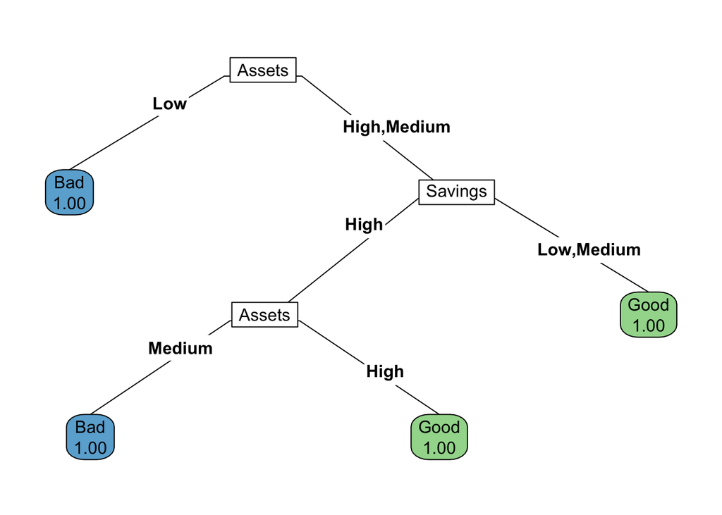

## Decision Trees Algorithms

There are many decision trees algorithm but the most famous one are `CART` and `C4.5` or the updated `C5.0`.

## Controling the behavior of Decision Tree

We can specify a many things related to the Tree Structure in the algorithm.

- Minimum number of observations that must exist in a node in order for a split to be attempted
- Complexity parameter : Any split that does not decrease the overall lack of fit by a factor of cp is not attempted

## Requirements For Using Decision Trees

- Decision tree algorithms represent supervised learning, and as such require preclassified target variables. A training data set must be supplied which provides the algorithm with the values of the target variable
- This training data set should be rich and varied, providing the algorithm with a healthy cross section of the types of records for which classification may be needed in the future. Decision trees learn by example, and if examples are systematically lacking for a definable subset of records, classification and prediction for this subset will be problematic or impossible
- The target attribute classes must be discrete. That is, one cannot apply decision tree analysis to a continuous target variable. Rather, the target variable must take on values that are clearly demarcated as either belonging to a particular class or not belonging

## C50 Alrogirthm

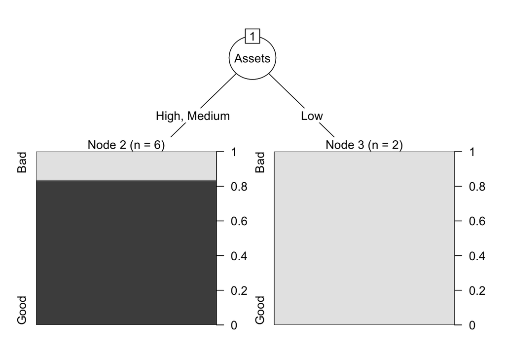

```r
predictors <- credit_risk[,c("Savings","Assets","Income")]
d_tree <-C5.0(x =predictors, y = credit_risk[,"CreditRisk"] ,control = C5.0Control(minCases = 2,earlyStopping = FALSE))
plot(d_tree)
```

# Boosting

Boosting is a popular way to improve predictions, particularly for decision trees. The main idea is that the model, or rather models, learn slowly through sequential fitting. First, a model is fit on the data with all observations having equal weight. Then the observations for which the model performed poorly are upweighted and the observations for which the model performed well are downweighted and a new model is fit. This process is repeated a set number of times and the final model is the accumulation of these little models

## Real Example with boosting

### Backgroaund

#### 1. Reading the data

Note: The data is stored in a space-separated text file with no headers where categorical data have been labeled with non-obvious codes. It would be better to review the data description provided by the *domain expert*.

```r
url_file <- "http://archive.ics.uci.edu/ml/machine-learning-databases/statlog/german/german.data"
credit <- read.table(file = url_file, sep =" ", header = FALSE)
```

#### 2. Preprocessing Data,

We will need to add the column names first.

```r
#Creating a column names vector and assign it to the data base
creditNames <- c ("Checking",
                  "Duration",
                  "CreditHistory",
                  "Purpose","CreditAmount",
                  "Savings",
                  "Employment","InstallmentRate",
                  "GenderMarital",
                  "OtherDebtors","YearsAtResidence",
                  "RealEstate",
                  "Age",
                  "OtherInstallment",
                  "Housing",
                  "ExistingCredits",
                  "Job",
                  "NumLiable",
                  "Phone",
                  "Foreign",
                  "Credit")

names(credit) <- creditNames
```

Now we have to translate those weird codes into meaningful values.

```r
credit_cln <- credit %>%

  mutate(CreditHistory= recode(CreditHistory,
                               A30="All Paid",
                               A31="All Paid This Bank",
                               A32="Up To Date",
                               A33="Late Payment",
                               A34="Critical Account")) %>%

  mutate(Purpose = recode(Purpose,
                          A40="car (new)",
                          A41="car (used)",
                          A42="furniture/equipment",
                          A43="radio/television",
                          A44="domestic appliances",
                          A45="repairs",
                          A46="education",
                          A47="(vacation - does not exist?)",
                          A48="retraining",
                          A49="business",
                          A410="others")) %>%

  mutate(Employment = recode(Employment,
                             A71="unemployed",
                             A72="< 1 year",
                             A73="1 - 4 years",
                             A74="4 - 7 years",
                             A75=">= 7 years")) %>%

  mutate(Credit = recode_factor(Credit,
                                "1"="Good",
                                "2"="Bad", .default = levels(c("Good", "Bad")))) %>%
  mutate(Gender = recode_factor(GenderMarital,
                                A91 ="male",
                                A92 = "female",
                                A93= "male",
                                A94= "male",
                                A95 = "female", .default = levels(c("male", "female")))) %>%
  mutate(Job = recode(Job,
                      A171 = "unemployed",
                      A172 = "unskilled",
                      A173 = "skilled employee",
                      A174 = "management")) %>%
  mutate(Phone = recode(Phone,
                        A191 = "No",
                        A192 = "Yes"
                        )) %>%
  mutate(Foreign = recode(Foreign,
                        A201 = "yes",
                        A202 = "no" )) %>%
  mutate(Housing = recode(Housing,
                          A151 = "rent",
                          A152 = "own",
                          A153 ="free")) %>%
  mutate(OtherInstallment = recode(OtherInstallment,
                                   A141 = "bank",
                                   A142 = "stores",
                                   A143 = "none")) %>%
  mutate(RealEstate = recode(RealEstate,
                             A121 = "real estate",
                             A122 = "life insurance",
                             A123 = "car or other",
                             A124 = "no property")) %>%
  mutate(Savings = recode(Savings,
                          A61 = "less than 100 DM",
                          A62 = "100 - 500 DM",
                          A63 = "500 - 1000 DM",
                          A64 = "more than 1000 DM",
                          A65 = "no savings account"
                          )) %>%
  mutate(OtherDebtors= recode(OtherDebtors,
                              A101 = "none",
                              A102 = "co-applicant",
                              A103 = "guarantor"
                              )) %>%
  mutate(Checking = recode(Checking,
                           A11 = "less than 0 DM",
                           A12 = "0 - 200 DM",
                           A13 = "more than 200 DM",
                           A14 = "no checking account" )) %>%  select(-GenderMarital) #%>%  anyNA()
```

#### 3. Feature Selection

We can select the features that we believe are most important to the model. This is usually done with the domain expert.

```r
sub_credit <- credit_cln %>% select(Credit, CreditHistory, Purpose, Employment, Duration, Age, CreditAmount)
```

#### 4. Build model

We now can construct our model in `formula` format for R

```r
Credit_Formula <- Credit ~ CreditHistory + Purpose + Employment +
Duration + Age + CreditAmount - 1
```

#### 5. Formulating the Design Matrix in order to use it for the xgboost

```r
creditX <- build.x(Credit_Formula, data=sub_credit, contrasts=FALSE)
creditY <- build.y(Credit_Formula, data=sub_credit)
creditY <- as.integer(relevel(creditY, ref = "Bad"))-1
```

#### 6. Building the model using the boosting method

The predictor `matrix` and response `vector` are supplied to the `data` and `label` arguments, respectively. The `nrounds` argument determines the number of passes on the data. Too many passes can lead to overfitting, so thought must go into this number. The learning rate is controlled by `eta` , with a lower number leading to less overfitting. The maximum depth of the trees is indicated by `max.depth` . Parallel processing is automatically enabled if OpenMP is present, and the number of parallel threads is controlled by the `nthread` argument. We specify the type of model with the `objective` argument.

```r
creditBoost <- xgboost (data=creditX, label=creditY, max.depth=3,
eta=.3, nthread=4, nrounds=20, objective="binary:logistic")
```

[output not shown]

#### 7. Making Prediction

we can make prediction by using the `predict` function. We have not split the data in this case, so we will just use some of the training data instead.

```r
set.seed(123)
test_data <- sub_credit[sample(100),]
test_x <- build.x(Credit_Formula, data=test_data, contrasts=FALSE)
preds <- predict(object = creditBoost, newdata =test_x )

preds <- ifelse(preds > 0.5, 1, 0)
```

#### 8. Evaluation

We can use `caret` confusion matrix to evaluate

```r
confusionMatrix(as.factor(preds),factor(test_data$Credit, levels = c("Good", "Bad"), labels = c(1,0)))
```

```
## Confusion Matrix and Statistics
##
##           Reference
## Prediction  1  0
##          1 71 12
##          0  4 13
##
##                Accuracy : 0.84
##                  95% CI : (0.7532, 0.9057)
##     No Information Rate : 0.75
##     P-Value [Acc > NIR] : 0.02111
##
##                   Kappa : 0.5224
##
##  Mcnemar's Test P-Value : 0.08012
##
##             Sensitivity : 0.9467
##             Specificity : 0.5200
##          Pos Pred Value : 0.8554
##          Neg Pred Value : 0.7647
##              Prevalence : 0.7500
##          Detection Rate : 0.7100
##    Detection Prevalence : 0.8300
##       Balanced Accuracy : 0.7333
##
##        'Positive' Class : 1
##
```